# PMLproject

pd

Saturday, August 22, 2015

## Abstract

The objective of this project is to build a machine learning model and use it to recognize human activities based on the Human Activity dataset from Groupware. Additional information for the data is available from the website at: http://groupware.les.inf.puc-rio.br/har. For this assignment, the provided data is used to build a model, train, and test the recognition of activity type that an individual performs. The Random forest method is used and the test results demonstartes a very high acuracy of the model’s performance. The correct answers for the 20 test-case scenarios of this assignment prove the validity of the approach.

## Data input and preprocessing

Import Data Sets - specifying the data sources and training / testing files destination. First, load the datasets from the links provided for training and test data. Preview the datasets. Some values containe a “#DIV/0!”, " “, or”NA" value. Columns with mostly missing values do not contribute to the training/prediction. It is reasonable to sellect features that have complete columns of data. Windows and timestamp are irrelevant to this assignment. Privacy dictate to remove the user name. Changing the values to numeric simplifies processing.

```r
setwd("C:/Users/Plamen/Documents")
training_data <- read.csv('pml-training.csv', na.strings = c("#DIV/0!", "NA", ""))
evaluation_data <- read.csv('pml-test.csv', na.strings = c("#DIV/0!", "NA", ""))
for(i in c(8:ncol(training_data)-1))
  training_data[,i] = as.numeric(as.character(training_data[,i]))
for(i in c(8:ncol(evaluation_data)-1))
  evaluation_data[,i] = as.numeric(as.character(evaluation_data[,i]))
```

Examine the features in the dataset, determine and display the features. Allocate the data for training (75%) and testing (25%) subsets.

```r
feature_set <- colnames(training_data[colSums(is.na(training_data)) == 0])[-(1:7)]
model_data <- training_data[feature_set]
feature_set
```

```
##  [1] "roll_belt"            "pitch_belt"           "yaw_belt"
##  [4] "total_accel_belt"     "gyros_belt_x"         "gyros_belt_y"
##  [7] "gyros_belt_z"         "accel_belt_x"         "accel_belt_y"
## [10] "accel_belt_z"         "magnet_belt_x"        "magnet_belt_y"
## [13] "magnet_belt_z"        "roll_arm"             "pitch_arm"
## [16] "yaw_arm"              "total_accel_arm"      "gyros_arm_x"
## [19] "gyros_arm_y"          "gyros_arm_z"          "accel_arm_x"
## [22] "accel_arm_y"          "accel_arm_z"          "magnet_arm_x"
## [25] "magnet_arm_y"         "magnet_arm_z"         "roll_dumbbell"
## [28] "pitch_dumbbell"       "yaw_dumbbell"         "total_accel_dumbbell"
## [31] "gyros_dumbbell_x"     "gyros_dumbbell_y"     "gyros_dumbbell_z"
## [34] "accel_dumbbell_x"     "accel_dumbbell_y"     "accel_dumbbell_z"
## [37] "magnet_dumbbell_x"    "magnet_dumbbell_y"    "magnet_dumbbell_z"
## [40] "roll_forearm"         "pitch_forearm"        "yaw_forearm"
## [43] "total_accel_forearm"  "gyros_forearm_x"      "gyros_forearm_y"
## [46] "gyros_forearm_z"      "accel_forearm_x"      "accel_forearm_y"
## [49] "accel_forearm_z"      "magnet_forearm_x"     "magnet_forearm_y"
## [52] "magnet_forearm_z"     "classe"
```

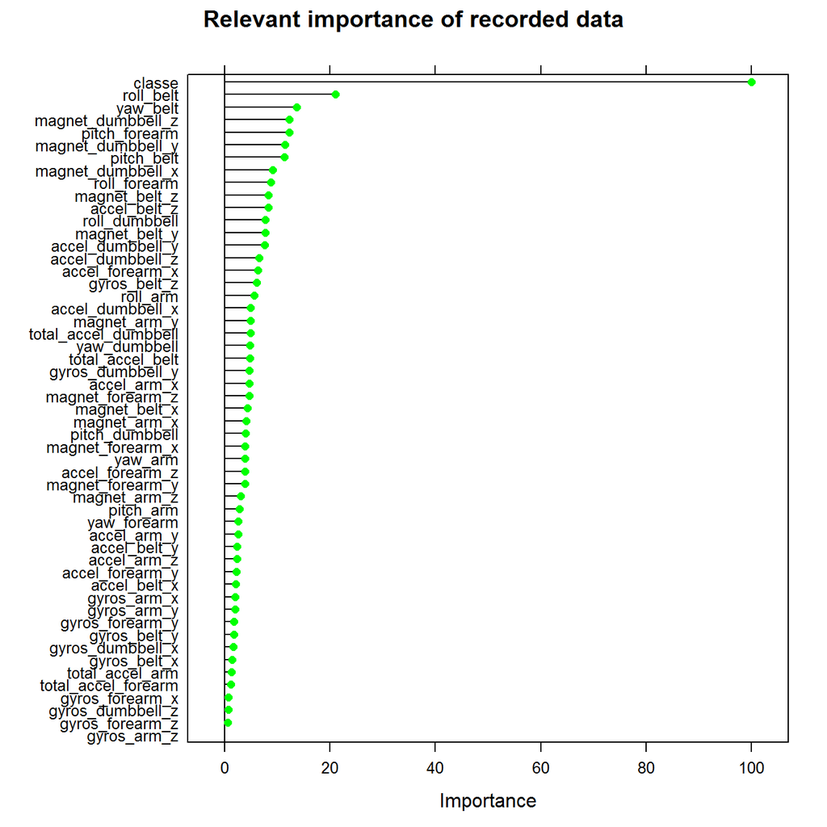

```r
index <- createDataPartition(y=model_data$classe, p=0.75, list=FALSE )
training <- model_data[index,]
testing <- model_data[-index,]
suppressWarnings(suppressMessages(library(randomForest)))
random.forest <- train(training[,-57], training$classe, tuneGrid=data.frame(mtry=3),
                       trControl=trainControl(method="none"))
plot(varImp(random.forest), col="green", main="Relevant importance of recorded data")
```

## Model training and testing

```r
suppressWarnings(suppressMessages(library(doParallel)))
registerDoParallel()
suppressWarnings(suppressMessages(library(foreach)))

x <- training[-ncol(training)]
y <- training$classe
rf <- foreach(ntree=rep(100, 2), .combine=randomForest::combine, .packages='randomForest') %dopar%
randomForest(x, y, ntree=ntree)
```

Examine the accuracy reports for training and test data to evaluate the overall performance of the model.

```r
predict_1 <- predict(rf, newdata=training)
CM1 <- confusionMatrix(predict_1,training$classe)
CM1$overall
```

```
##       Accuracy          Kappa  AccuracyLower  AccuracyUpper   AccuracyNull
##      1.0000000      1.0000000      0.9997494      1.0000000      0.2843457
## AccuracyPValue  McnemarPValue
##      0.0000000            NaN
```

```r
predict_2 <- predict(rf, newdata=testing)
CM2 <- confusionMatrix(predict_2,testing$classe)
CM2$overall
```

```
##       Accuracy          Kappa  AccuracyLower  AccuracyUpper   AccuracyNull
##      0.9953100      0.9940674      0.9929709      0.9970247      0.2844617
## AccuracyPValue  McnemarPValue
##      0.0000000            NaN
```

## Generate submission files

Prepare the output files for submission using Coursera provided code.

```r
pml_write_files = function(x){
  n = length(x)
  for(i in 1:n){
    filename = paste0("problem_id_",i,".txt")
    write.table(x[i],file=filename,quote=FALSE,row.names=FALSE,col.names=FALSE)
  }
}


x <- evaluation_data
x <- x[feature_set[feature_set!='classe']]
answers <- predict(rf, newdata=x)

answers
```

```
##  1  2  3  4  5  6  7  8  9 10 11 12 13 14 15 16 17 18 19 20
##  B  A  B  A  A  E  D  B  A  A  B  C  B  A  E  E  A  B  B  B
## Levels: A B C D E
```

```r
pml_write_files(answers)
```